# air_traffic_concentration

Lucas Martins Sorge

2025-04-27

## Introduction

This report investigates how global air traffic is distributed across airports using the OpenFlights dataset.  
We analyze the concentration of flights among airports by visualizing the Lorenz Curve, calculating the Gini coefficient, and identifying top-contributing airports.

## Airport Traffic Concentration Analysis

## Lorenz Curve of Airport Traffic

We first examine the distribution of total flight traffic among airports

```r
# Arrange airports by descending total flight traffic
# Calculate cumulative sums and percentages for Lorenz curve plotting
flight_traffic_sorted <- flight_traffic %>%
  arrange(desc(flight_traffic)) %>%
  mutate(
    cumulative_flights = cumsum(flight_traffic),
    total_flights = sum(flight_traffic),
    cumulative_percent = cumulative_flights / total_flights,
    airport_percent = row_number() / n()
  )

head(flight_traffic_sorted)
```

```
## # A tibble: 6 × 6
##   iata  flight_traffic cumulative_flights total_flights cumulative_percent
##   <chr>          <dbl>              <dbl>         <dbl>              <dbl>
## 1 ATL             1826               1826        134458             0.0136
## 2 ORD             1108               2934        134458             0.0218
## 3 PEK             1069               4003        134458             0.0298
## 4 LHR             1047               5050        134458             0.0376
## 5 CDG             1041               6091        134458             0.0453
## 6 FRA              990               7081        134458             0.0527
## # ℹ 1 more variable: airport_percent <dbl>
```

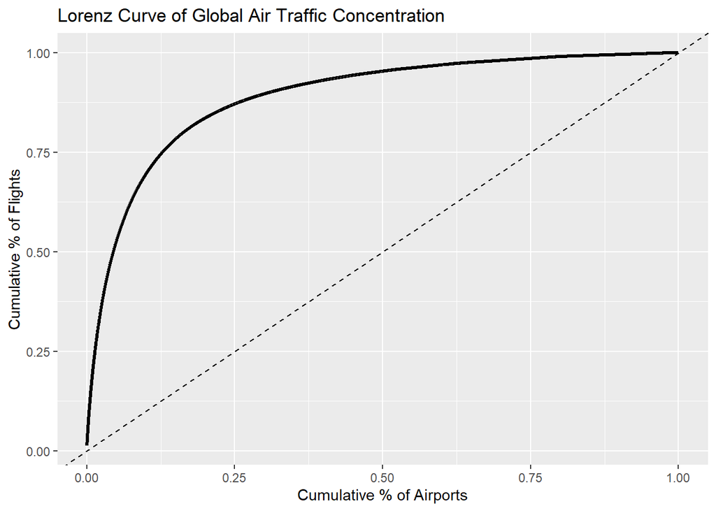

```r
# Plot the Lorenz Curve
ggplot(flight_traffic_sorted, aes(x = airport_percent, y = cumulative_percent)) +
  geom_line(color = "black", linewidth = 1.2) +
  geom_abline(intercept = 0, slope = 1, linetype = "dashed") +
  labs(
    title = "Lorenz Curve of Global Air Traffic Concentration",
    x = "Cumulative % of Airports",
    y = "Cumulative % of Flights"
  )
```

## Gini Coefficient Calculation

We compute the Gini coefficient to numerically measure the inequality in flight distribution across airports.

```r
# Calculate Gini Coefficient to quantify inequality of flight distribution
gini_coefficient <- ineq(flight_traffic_sorted$flight_traffic, type = "Gini")
gini_coefficient
```

```
## [1] 0.7793184
```

### Interpretation

The Gini coefficient is approximately **0.78**, confirming that global air traffic is highly concentrated among a few airports.

## Flight Concentration by Airport Percentile

We analyze what proportion of total flights are handled by the top 1%, 5%, and 10% of airports.

```r
# Concentration at different thresholds
top_1_percent_threshold <- flight_traffic_sorted %>%
  filter(airport_percent <= 0.01) %>%
  summarise(percent_flights = max(cumulative_percent)) %>%
  pull(percent_flights)

top_5_percent_threshold <- flight_traffic_sorted %>%
  filter(airport_percent <= 0.05) %>%
  summarise(percent_flights = max(cumulative_percent)) %>%
  pull(percent_flights)

top_10_percent_threshold <- flight_traffic_sorted %>%
  filter(airport_percent <= 0.10) %>%
  summarise(percent_flights = max(cumulative_percent)) %>%
  pull(percent_flights)

cat("Top 1% of airports handle about", round(top_1_percent_threshold*100, 1), "% of flights.\n")
```

```
## Top 1% of airports handle about 19.8 % of flights.
```

```r
cat("Top 5% of airports handle about", round(top_5_percent_threshold*100, 1), "% of flights.\n")
```

```
## Top 5% of airports handle about 52.6 % of flights.
```

```r
cat("Top 10% of airports handle about", round(top_10_percent_threshold*100, 1), "% of flights.\n")
```

```
## Top 10% of airports handle about 69.5 % of flights.
```

### Interpretation

- The top **1%** of airports handle about **20%** of all flights.
- The top **5%** of airports handle about **53%** of all flights.
- The top **10%** of airports handle about **70%** of all flights.

These findings demonstrate the extreme concentration of air traffic at a small number of major hubs.

## Top 10 Airports by Total Flights

Finally, we identify the top airports contributing the most to global traffic.

```r
# Top 10 airports by traffic
top_airports_table <- flight_traffic_sorted %>%
  slice_max(flight_traffic, n = 10) %>%
  select(iata, flight_traffic, cumulative_percent)

top_airports_table
```

```
## # A tibble: 10 × 3
##    iata  flight_traffic cumulative_percent
##    <chr>          <dbl>              <dbl>
##  1 ATL             1826             0.0136
##  2 ORD             1108             0.0218
##  3 PEK             1069             0.0298
##  4 LHR             1047             0.0376
##  5 CDG             1041             0.0453
##  6 FRA              990             0.0527
##  7 LAX              990             0.0600
##  8 DFW              936             0.0670
##  9 JFK              911             0.0738
## 10 AMS              903             0.0805
```

## Conclusion

Our analysis shows that global air traffic is highly concentrated.

The Lorenz Curve and a high Gini coefficient (~0.78) confirm that a small percentage of airports handle a disproportionately large share of flights.

This concentration reflects the critical role of a limited number of international hubs in global aviation connectivity.